# Biostat 203B Homework 3

Due Feb 22 @ 11:59PM

Author

Charlotte Lee and 206782165

Load necessary libraries (you can add more as needed).

```r
library(arrow)
library(gtsummary)
library(memuse)
#library(pryr) didn't work for my version of R
library(lobstr)
library(R.utils)
library(tidyverse)
library(styler)
```

Display your machine memory.

```r
memuse::Sys.meminfo()
```

```
Totalram:  16.000 GiB
Freeram:    3.823 GiB
```

In this exercise, we use tidyverse (ggplot2, dplyr, etc) to explore the [MIMIC-IV](https://physionet.org/content/mimiciv/3.1/) data introduced in [homework 1](https://ucla-biostat-203b.github.io/2026winter/hw/hw1/hw1.html) and to build a cohort of ICU stays.

## Q1. Visualizing patient trajectory

Visualizing a patient’s encounters in a health care system is a common task in clinical data analysis. In this question, we will visualize a patient’s ADT (admission-discharge-transfer) history and ICU vitals in the MIMIC-IV data.

### Q1.1 ADT history

Hint: We need to pull information from data files `patients.csv.gz`, `admissions.csv.gz`, `transfers.csv.gz`, `labevents.csv.gz`, `procedures_icd.csv.gz`, `diagnoses_icd.csv.gz`, `d_icd_procedures.csv.gz`, and `d_icd_diagnoses.csv.gz`. For the big file `labevents.csv.gz`, use the Parquet format you generated in Homework 2. For reproducibility, make the Parquet folder `labevents_pq` available at the current working directory `hw3`, for example, by a symbolic link. Make your code reproducible.

```bash
#ls ~/Documents
#ls ~/Documents/biostat-203b-2026-winter
#ls ~/Documents/biostat-203b-2026-winter/hw2

ls ~/Downloads/mimic-iv-3.1/hosp
ls ~/Downloads/mimic-iv-3.1/icu

gzcat ~/Downloads/mimic-iv-3.1/hosp/admissions.csv.gz | head -n 2
```

```r
library(arrow)
library(readr)
library(dplyr)
library(fs)

csv_file <- "~/Downloads/mimic-iv-3.1/hosp/labevents.csv.gz"
parquet_dir <- "~/Downloads/mimic-iv-3.1/hosp/labevents_pq"

# Remove old folder
unlink(parquet_dir, recursive = TRUE)
Sys.sleep(2)

# Just do the conversion directly - let Arrow handle it
arrow::read_csv_arrow(csv_file) %>%
  arrow::write_dataset(parquet_dir, format = "parquet")

cat("Done!\n")

# Check the files
files <- list.files("~/Downloads/mimic-iv-3.1/hosp/labevents_pq/", pattern = "parquet$")
cat(sprintf("Created %d parquet files\n", length(files)))

# Check sizes
parquet_dir <- "~/Downloads/mimic-iv-3.1/hosp/labevents_pq"
sizes_mb <- sum(file.info(list.files(parquet_dir, full.names = TRUE))$size) / 1024^2
cat(sprintf("Total size: %.0f MB\n", sizes_mb))

# Verify you can read it
library(arrow)
ds <- arrow::open_dataset(parquet_dir, format = "parquet")
n_rows <- ds %>% count() %>% collect() %>% pull(n)
cat(sprintf("Total rows: %d\n", n_rows))
```

```bash
#ln -s ~/Downloads/mimic-iv-3.1/hosp/labevents_pq ./labevents_pq
#ls -la labevents_pq/

cd ~/Documents/biostat-203b-2026-winter/hw3
ln -s ~/Downloads/mimic-iv-3.1/hosp/labevents_pq ./labevents_pq
```

```r
library(tidyverse)
library(arrow)
library(lubridate)

# Changeable
subject_id_input <- 10063848

# Load tables
mimic_path <- "../../../Downloads/mimic-iv-3.1/hosp"
patients   <- read_csv(gzfile(file.path(mimic_path, "patients.csv.gz")), show_col_types = FALSE)
admissions <- read_csv(gzfile(file.path(mimic_path, "admissions.csv.gz")), show_col_types = FALSE)
transfers  <- read_csv(gzfile(file.path(mimic_path, "transfers.csv.gz")), show_col_types = FALSE)
procedures <- read_csv(gzfile(file.path(mimic_path, "procedures_icd.csv.gz")), show_col_types = FALSE)
diagnoses  <- read_csv(gzfile(file.path(mimic_path, "diagnoses_icd.csv.gz")), show_col_types = FALSE)
d_proc     <- read_csv(gzfile(file.path(mimic_path, "d_icd_procedures.csv.gz")), show_col_types = FALSE)
d_diag     <- read_csv(gzfile(file.path(mimic_path, "d_icd_diagnoses.csv.gz")), show_col_types = FALSE)

# Load parquet from your symlink
labs <- open_dataset("./labevents_pq", format = "parquet")

# Patient Info & Top 3 diagnoses
patient_info <- patients %>%
  filter(subject_id == subject_id_input)

top_diag <- diagnoses %>%
  filter(subject_id == subject_id_input) %>%
  left_join(d_diag, by = "icd_code") %>%
  slice_head(n = 3) %>%
  pull(long_title)

# ADT Transfers
adt <- transfers %>%
  filter(subject_id == subject_id_input) %>%
  mutate(
    intime  = ymd_hms(intime),
    outtime = ymd_hms(outtime),
    is_icu  = str_detect(careunit, "ICU|CCU")
  )

# Lab events
lab_itemids <- c(50862, 50912, 50971, 50983, 50902, 50882, 51221, 51301, 50931)

lab_events <- labs %>%
  filter(subject_id == subject_id_input, itemid %in% lab_itemids) %>%
  select(charttime) %>%
  collect() %>%
  mutate(charttime = ymd_hms(charttime)) %>%
  distinct()

# Procedures
proc_events <- procedures %>%
  filter(subject_id == subject_id_input) %>%
  left_join(d_proc, by = "icd_code") %>%
  mutate(charttime = ymd(chartdate))

# Building Titles/Subtitles
age <- patient_info$anchor_age
title_text <- paste0(
  "Patient ", subject_id_input, ", ",
  patient_info$gender, ", ",
  age, " years old, ",
  patient_info$race
)
subtitle_text <- paste(top_diag, collapse = "\n")
```

[figure not shown]

```r
#FINAL VISUALIZATION

ggplot() +
  # ADT segments
  geom_segment(
    data = adt,
    aes(x = intime, xend = outtime,
        y = "ADT", yend = "ADT",
        color = careunit,
        linewidth = is_icu)
  ) +
  # Lab crosses
  geom_point(
    data = lab_events,
    aes(x = charttime, y = "Lab"),
    shape = 3,
    size = 2
  ) +
  # Procedures
  geom_point(
    data = proc_events,
    aes(x = charttime,
        y = "Procedure",
        shape = long_title),
    size = 3
  ) +
  scale_linewidth_manual(values = c(0.7, 2), guide = "none") +
  scale_y_discrete(limits = rev) +
  labs(
    title = title_text,
    subtitle = subtitle_text,
    x = "Calendar Time",
    y = NULL,
    color = "Care Unit",
    shape = "Procedure"
  ) +
  theme_minimal(base_size = 14) +
  theme(
    plot.title = element_text(face = "bold", size = 18),
    plot.subtitle = element_text(size = 14),
    legend.position = "bottom",
    axis.text.y = element_text(size = 13)
  )
```

### Q1.2 ICU stays

```bash
#gunzip -c ~/Downloads/mimic-iv-3.1/icu/d_items.csv.gz | grep -E "HR|NBPd|NBPs|RR|Temperature"

#vital_itemids <- c(
 # 220045,  # HR
 # 220179,  # NBPs (systolic)
 # 220180,  # NBPd (diastolic)
 # 220210,  # RR
#  223761  ) # Temperature Fahrenheit
```

```r
library(tidyverse)
library(arrow)
library(lubridate)

# Configuration
subject_id_input <- 10063848
icu_path <- "../../../Downloads/mimic-iv-3.1/icu"
hosp_path <- "../../../Downloads/mimic-iv-3.1/hosp"

# Load small files with read_csv
icustays <- read_csv(gzfile(file.path(icu_path, "icustays.csv.gz")), show_col_types = FALSE)
d_items <- read_csv(gzfile(file.path(icu_path, "d_items.csv.gz")), show_col_types = FALSE)

# Use Arrow to read large chartevents - much faster!
vital_itemids <- c(220045, 220179, 220180, 220210, 223761)

chartevents_dataset <- open_dataset(file.path(icu_path, "chartevents.csv.gz"), format = "csv")

vitals_icu <- chartevents_dataset %>%
  filter(subject_id == subject_id_input, itemid %in% vital_itemids) %>%
  select(stay_id, charttime, itemid, valuenum) %>%
  collect() %>%
  mutate(charttime = ymd_hms(charttime)) %>%
  filter(!is.na(valuenum)) %>%
  left_join(d_items %>% select(itemid, abbreviation), by = "itemid") %>%
  inner_join(
    icustays %>%
      filter(subject_id == subject_id_input) %>%
      mutate(intime = ymd_hms(intime), outtime = ymd_hms(outtime)) %>%
      select(stay_id, intime, outtime),
    by = "stay_id"
  ) %>%
  filter(charttime >= intime & charttime <= outtime) %>%
  select(stay_id, charttime, abbreviation, valuenum)
# Create plot
p <- ggplot(vitals_icu, aes(x = charttime, y = valuenum, color = abbreviation)) +
  geom_point(size = 2) +
  geom_line(alpha = 0.6) +
  facet_grid(abbreviation ~ stay_id, scales = "free_y") +
  labs(
    title = sprintf("Patient %d ICU stays - Vitals", subject_id_input),
    x = "Calendar Time",
    y = "Value"
  ) +
  theme_minimal() +
  theme(
    plot.title = element_text(face = "bold", size = 16),
    axis.text.x = element_text(angle = 45, hjust = 1, size = 9),
    legend.position = "right"
  )

#print(p)
#ggsave("icu_vitals_10063848.png", width = 16, height = 10, dpi = 300)
#cat("✓ Saved: icu_vitals_10063848.png\n")
```

[output not shown]

## Q2. ICU stays

`icustays.csv.gz` (https://mimic.mit.edu/docs/iv/modules/icu/icustays/) contains data about Intensive Care Units (ICU) stays. The first 10 lines are

```bash
zcat < ~/mimic/icu/icustays.csv.gz | head
```

```
subject_id,hadm_id,stay_id,first_careunit,last_careunit,intime,outtime,los
10000032,29079034,39553978,Medical Intensive Care Unit (MICU),Medical Intensive Care Unit (MICU),2180-07-23 14:00:00,2180-07-23 23:50:47,0.4102662037037037
10000690,25860671,37081114,Medical Intensive Care Unit (MICU),Medical Intensive Care Unit (MICU),2150-11-02 19:37:00,2150-11-06 17:03:17,3.8932523148148146
10000980,26913865,39765666,Medical Intensive Care Unit (MICU),Medical Intensive Care Unit (MICU),2189-06-27 08:42:00,2189-06-27 20:38:27,0.4975347222222222
10001217,24597018,37067082,Surgical Intensive Care Unit (SICU),Surgical Intensive Care Unit (SICU),2157-11-20 19:18:02,2157-11-21 22:08:00,1.1180324074074075
10001217,27703517,34592300,Surgical Intensive Care Unit (SICU),Surgical Intensive Care Unit (SICU),2157-12-19 15:42:24,2157-12-20 14:27:41,0.948113425925926
10001725,25563031,31205490,Medical/Surgical Intensive Care Unit (MICU/SICU),Medical/Surgical Intensive Care Unit (MICU/SICU),2110-04-11 15:52:22,2110-04-12 23:59:56,1.338587962962963
10001843,26133978,39698942,Medical/Surgical Intensive Care Unit (MICU/SICU),Medical/Surgical Intensive Care Unit (MICU/SICU),2134-12-05 18:50:03,2134-12-06 14:38:26,0.8252662037037037
10001884,26184834,37510196,Medical Intensive Care Unit (MICU),Medical Intensive Care Unit (MICU),2131-01-11 04:20:05,2131-01-20 08:27:30,9.17181712962963
10002013,23581541,39060235,Cardiac Vascular Intensive Care Unit (CVICU),Cardiac Vascular Intensive Care Unit (CVICU),2160-05-18 10:00:53,2160-05-19 17:33:33,1.314351851851852
```

### Q2.1 Ingestion

Import `icustays.csv.gz` as a tibble `icustays_tble`.

```r
icustays_tble <- read_csv(gzfile(file.path(icu_path, "icustays.csv.gz")), show_col_types = FALSE)


icustays_tble <- read_csv(gzfile(file.path(icu_path, "icustays.csv.gz")), show_col_types = FALSE) %>%
  as_tibble()
```

### Q2.2 Summary and visualization

How many unique `subject_id`? Can a `subject_id` have multiple ICU stays? Summarize the number of ICU stays per `subject_id` by graphs.

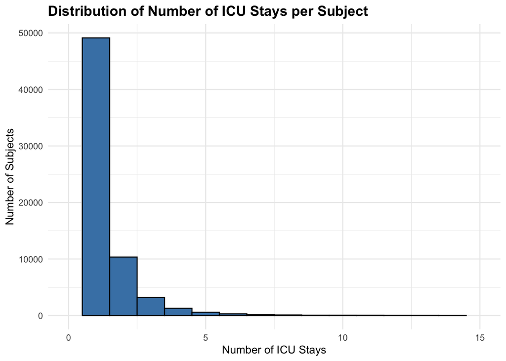

```r
library(tidyverse)

icu_path <- "../../../Downloads/mimic-iv-3.1/icu"

# Load icustays as tibble
icustays_tble <- read_csv(gzfile(file.path(icu_path, "icustays.csv.gz")), show_col_types = FALSE)

# Summarize: number of ICU stays per subject_id
stays_per_subject <- icustays_tble %>%
  group_by(subject_id) %>%
  summarize(n_stays = n(), .groups = "drop")

# Graph 1: Histogram of ICU stays distribution
p1 <- ggplot(stays_per_subject, aes(x = n_stays)) +
  geom_histogram(binwidth = 1, fill = "steelblue", color = "black") +
  scale_x_continuous(limits = c(0, 15)) +  # Limit x-axis to 0-30
  labs(
    title = "Distribution of Number of ICU Stays per Subject",
    x = "Number of ICU Stays",
    y = "Number of Subjects"
  ) +
  theme_minimal() +
  theme(plot.title = element_text(face = "bold", size = 14))

# Graph 2: Density plot
p2 <- ggplot(stays_per_subject, aes(x = n_stays)) +
  geom_density(fill = "steelblue", alpha = 0.6) +
  scale_x_continuous(limits = c(0, 15)) +  # Limit x-axis to 0-30
  labs(
    title = "Density of Number of ICU Stays per Subject",
    x = "Number of ICU Stays",
    y = "Density"
  ) +
  theme_minimal() +
  theme(plot.title = element_text(face = "bold", size = 14))

# Graph 3: Box plot (no x-axis limit needed)
p3 <- ggplot(stays_per_subject, aes(y = n_stays)) +
  geom_boxplot(fill = "steelblue") +
  scale_y_continuous(limits = c(0, 50)) +  # Limit y-axis to 0-30
  labs(
    title = "Box Plot of ICU Stays per Subject",
    y = "Number of ICU Stays"
  ) +
  theme_minimal() +
  theme(plot.title = element_text(face = "bold", size = 14))

print(p1)
```

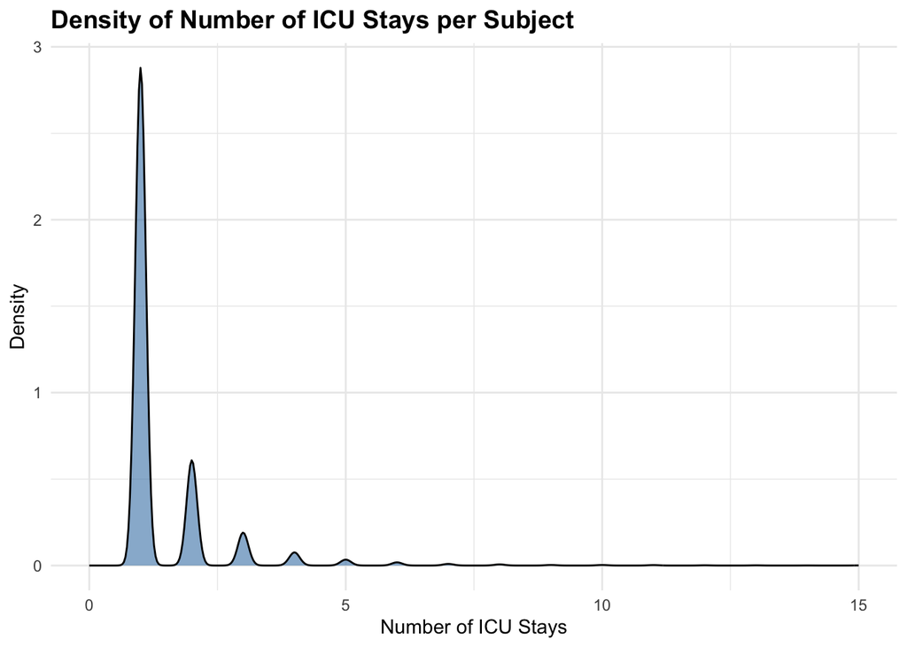

```r
print(p2)
```

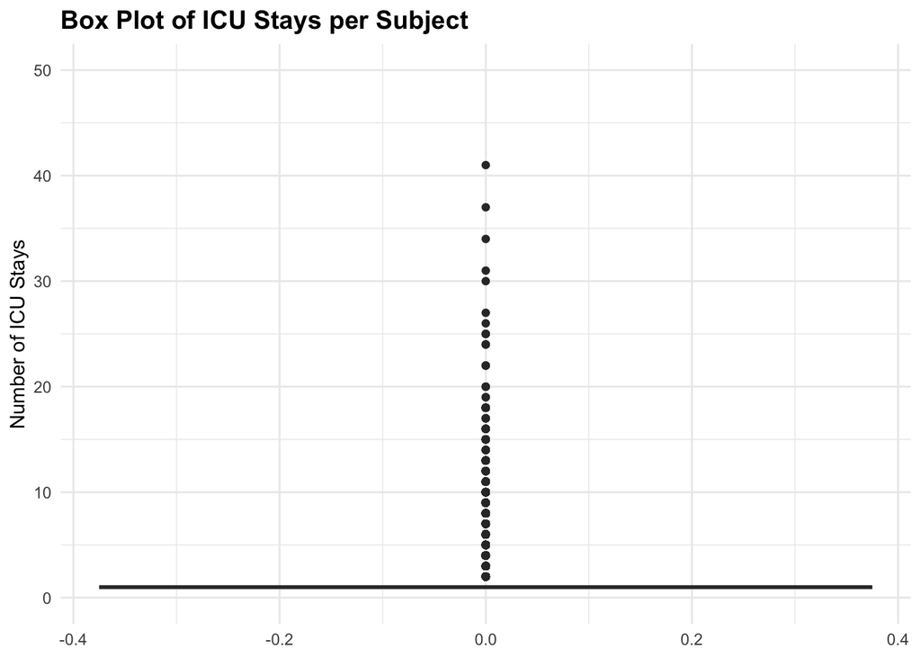

```r
print(p3)
```

## Q3. `admissions` data

Information of the patients admitted into hospital is available in `admissions.csv.gz`. See https://mimic.mit.edu/docs/iv/modules/hosp/admissions/ for details of each field in this file. The first 10 lines are

```bash
zcat < ~/mimic/hosp/admissions.csv.gz | head
```

[output not shown]

### Q3.1 Ingestion

Import `admissions.csv.gz` as a tibble `admissions_tble`.

### Q3.2 Summary and visualization

Summarize the following information by graphics and explain any patterns you see.

- number of admissions per patient
- admission hour (anything unusual?)
- admission minute (anything unusual?)
- length of hospital stay (from admission to discharge) (anything unusual?)

According to the [MIMIC-IV documentation](https://mimic.mit.edu/docs/iv/about/concepts/#date-shifting),

> All dates in the database have been shifted to protect patient confidentiality. Dates will be internally consistent for the same patient, but randomly distributed in the future. Dates of birth which occur in the present time are not true dates of birth. Furthermore, dates of birth which occur before the year 1900 occur if the patient is older than 89. In these cases, the patient’s age at their first admission has been fixed to 300.

## Q4. `patients` data

Patient information is available in `patients.csv.gz`. See https://mimic.mit.edu/docs/iv/modules/hosp/patients/ for details of each field in this file. The first 10 lines are

```bash
zcat < ~/mimic/hosp/patients.csv.gz | head
```

```
subject_id,gender,anchor_age,anchor_year,anchor_year_group,dod
10000032,F,52,2180,2014 - 2016,2180-09-09
10000048,F,23,2126,2008 - 2010,
10000058,F,33,2168,2020 - 2022,
10000068,F,19,2160,2008 - 2010,
10000084,M,72,2160,2017 - 2019,2161-02-13
10000102,F,27,2136,2008 - 2010,
10000108,M,25,2163,2014 - 2016,
10000115,M,24,2154,2017 - 2019,
10000117,F,48,2174,2008 - 2010,
```

### Q4.1 Ingestion

Import `patients.csv.gz` (https://mimic.mit.edu/docs/iv/modules/hosp/patients/) as a tibble `patients_tble`.

### Q4.2 Summary and visualization

Summarize variables `gender` and `anchor_age` by graphics, and explain any patterns you see.

## Q5. Lab results

`labevents.csv.gz` (https://mimic.mit.edu/docs/iv/modules/hosp/labevents/) contains all laboratory measurements for patients. The first 10 lines are

```bash
zcat < ~/mimic/hosp/labevents.csv.gz | head
```

```
labevent_id,subject_id,hadm_id,specimen_id,itemid,order_provider_id,charttime,storetime,value,valuenum,valueuom,ref_range_lower,ref_range_upper,flag,priority,comments
1,10000032,,2704548,50931,P69FQC,2180-03-23 11:51:00,2180-03-23 15:56:00,___,95,mg/dL,70,100,,ROUTINE,"IF FASTING, 70-100 NORMAL, >125 PROVISIONAL DIABETES."
2,10000032,,36092842,51071,P69FQC,2180-03-23 11:51:00,2180-03-23 16:00:00,NEG,,,,,,ROUTINE,
3,10000032,,36092842,51074,P69FQC,2180-03-23 11:51:00,2180-03-23 16:00:00,NEG,,,,,,ROUTINE,
4,10000032,,36092842,51075,P69FQC,2180-03-23 11:51:00,2180-03-23 16:00:00,NEG,,,,,,ROUTINE,"BENZODIAZEPINE IMMUNOASSAY SCREEN DOES NOT DETECT SOME DRUGS,;INCLUDING LORAZEPAM, CLONAZEPAM, AND FLUNITRAZEPAM."
5,10000032,,36092842,51079,P69FQC,2180-03-23 11:51:00,2180-03-23 16:00:00,NEG,,,,,,ROUTINE,
6,10000032,,36092842,51087,P69FQC,2180-03-23 11:51:00,,,,,,,,ROUTINE,RANDOM.
7,10000032,,36092842,51089,P69FQC,2180-03-23 11:51:00,2180-03-23 16:15:00,,,,,,,ROUTINE,PRESUMPTIVELY POSITIVE.
8,10000032,,36092842,51090,P69FQC,2180-03-23 11:51:00,2180-03-23 16:00:00,NEG,,,,,,ROUTINE,METHADONE ASSAY DETECTS ONLY METHADONE (NOT OTHER OPIATES/OPIOIDS).
9,10000032,,36092842,51092,P69FQC,2180-03-23 11:51:00,2180-03-23 16:00:00,NEG,,,,,,ROUTINE,"OPIATE IMMUNOASSAY SCREEN DOES NOT DETECT SYNTHETIC OPIOIDS;SUCH AS METHADONE, OXYCODONE, FENTANYL, BUPRENORPHINE, TRAMADOL,;NALOXONE, MEPERIDINE.  SEE ONLINE LAB MANUAL FOR DETAILS."
```

`d_labitems.csv.gz` (https://mimic.mit.edu/docs/iv/modules/hosp/d_labitems/) is the dictionary of lab measurements.

```bash
zcat < ~/mimic/hosp/d_labitems.csv.gz | head
```

```
itemid,label,fluid,category
50801,Alveolar-arterial Gradient,Blood,Blood Gas
50802,Base Excess,Blood,Blood Gas
50803,"Calculated Bicarbonate, Whole Blood",Blood,Blood Gas
50804,Calculated Total CO2,Blood,Blood Gas
50805,Carboxyhemoglobin,Blood,Blood Gas
50806,"Chloride, Whole Blood",Blood,Blood Gas
50808,Free Calcium,Blood,Blood Gas
50809,Glucose,Blood,Blood Gas
50810,"Hematocrit, Calculated",Blood,Blood Gas
```

We are interested in the lab measurements of albumin (50862), creatinine (50912), potassium (50971), sodium (50983), chloride (50902), bicarbonate (50882), hematocrit (51221), white blood cell count (51301), and glucose (50931). Retrieve a subset of `labevents.csv.gz` that only containing these items for the patients in `icustays_tble`. Further restrict to the last available measurement (by `storetime`) before the ICU stay. The final `labevents_tble` should have one row per ICU stay and columns for each lab measurement.

[figure not shown]

Hint: Use the Parquet format you generated in Homework 2. For reproducibility, make `labevents_pq` folder available at the current working directory `hw3`, for example, by a symbolic link.

## Q6. Vitals from charted events

`chartevents.csv.gz` (https://mimic.mit.edu/docs/iv/modules/icu/chartevents/) contains all the charted data available for a patient. During their ICU stay, the primary repository of a patient’s information is their electronic chart. The `itemid` variable indicates a single measurement type in the database. The `value` variable is the value measured for `itemid`. The first 10 lines of `chartevents.csv.gz` are

```bash
zcat < ~/mimic/icu/chartevents.csv.gz | head
```

```
subject_id,hadm_id,stay_id,caregiver_id,charttime,storetime,itemid,value,valuenum,valueuom,warning
10000032,29079034,39553978,18704,2180-07-23 12:36:00,2180-07-23 14:45:00,226512,39.4,39.4,kg,0
10000032,29079034,39553978,18704,2180-07-23 12:36:00,2180-07-23 14:45:00,226707,60,60,Inch,0
10000032,29079034,39553978,18704,2180-07-23 12:36:00,2180-07-23 14:45:00,226730,152,152,cm,0
10000032,29079034,39553978,18704,2180-07-23 14:00:00,2180-07-23 14:18:00,220048,SR (Sinus Rhythm),,,0
10000032,29079034,39553978,18704,2180-07-23 14:00:00,2180-07-23 14:18:00,224642,Oral,,,0
10000032,29079034,39553978,18704,2180-07-23 14:00:00,2180-07-23 14:18:00,224650,None,,,0
10000032,29079034,39553978,18704,2180-07-23 14:00:00,2180-07-23 14:20:00,223761,98.7,98.7,°F,0
10000032,29079034,39553978,18704,2180-07-23 14:11:00,2180-07-23 14:17:00,220179,84,84,mmHg,0
10000032,29079034,39553978,18704,2180-07-23 14:11:00,2180-07-23 14:17:00,220180,48,48,mmHg,0
```

`d_items.csv.gz` (https://mimic.mit.edu/docs/iv/modules/icu/d_items/) is the dictionary for the `itemid` in `chartevents.csv.gz`.

```bash
zcat < ~/mimic/icu/d_items.csv.gz | head
```

```
itemid,label,abbreviation,linksto,category,unitname,param_type,lownormalvalue,highnormalvalue
220001,Problem List,Problem List,chartevents,General,,Text,,
220003,ICU Admission date,ICU Admission date,datetimeevents,ADT,,Date and time,,
220045,Heart Rate,HR,chartevents,Routine Vital Signs,bpm,Numeric,,
220046,Heart rate Alarm - High,HR Alarm - High,chartevents,Alarms,bpm,Numeric,,
220047,Heart Rate Alarm - Low,HR Alarm - Low,chartevents,Alarms,bpm,Numeric,,
220048,Heart Rhythm,Heart Rhythm,chartevents,Routine Vital Signs,,Text,,
220050,Arterial Blood Pressure systolic,ABPs,chartevents,Routine Vital Signs,mmHg,Numeric,90,140
220051,Arterial Blood Pressure diastolic,ABPd,chartevents,Routine Vital Signs,mmHg,Numeric,60,90
220052,Arterial Blood Pressure mean,ABPm,chartevents,Routine Vital Signs,mmHg,Numeric,,
```

We are interested in the vitals for ICU patients: heart rate (220045), systolic non-invasive blood pressure (220179), diastolic non-invasive blood pressure (220180), body temperature in Fahrenheit (223761), and respiratory rate (220210). Retrieve a subset of `chartevents.csv.gz` only containing these items for the patients in `icustays_tble`. Further restrict to the first vital measurement (by `storetime`) within the ICU stay. The final `chartevents_tble` should have one row per ICU stay and columns for each vital measurement.

[figure not shown]

Hint: Use the Parquet format you generated in Homework 2. For reproducibility, make `chartevents_pq` folder available at the current working directory, for example, by a symbolic link.

## Q7. Putting things together

Let us create a tibble `mimic_icu_cohort` for all ICU stays, where rows are all ICU stays of adults (age at `intime` >= 18) and columns contain at least following variables

- all variables in `icustays_tble`
- all variables in `admissions_tble`
- all variables in `patients_tble`
- the last lab measurements before the ICU stay in `labevents_tble`
- the first vital measurements during the ICU stay in `chartevents_tble`

The final `mimic_icu_cohort` should have one row per ICU stay and columns for each variable.

[figure not shown]

## Q8. Exploratory data analysis (EDA)

Summarize the following information about the ICU stay cohort `mimic_icu_cohort` using appropriate numerics or graphs:

- Length of ICU stay `los` vs demographic variables (race, insurance, marital_status, gender, age at intime)
- Length of ICU stay `los` vs the last available lab measurements before ICU stay
- Length of ICU stay `los` vs the first vital measurements within the ICU stay
- Length of ICU stay `los` vs first ICU unit

## Q9. AI assistant

Which AI assistants (e.g., GitHub Copilot) do you use when working on this assignment? Which AI model (e.g., GPT-5 mini, GPT-5, Claude Sonnet 4.5) does the AI assistant use? How do you use them? Do you think they help improve your productivity?

Give 5 instances where AI model gave incorrect or misleading answers. You can use screenshots or copy-paste the Q&A.